# FinalProjectReport_TG

Author

Tom George, Leena Al Khalili

# 1 Overview of Problem

The goal of this project is to build a multi-class classification model to predict a customer’s Credit Score (Poor, Standard, Good) using demographic and financial behavior data. This can support automated risk assessment in financial institutions and reduce manual workload.

# 2 About Dataset

**Source :** Kaggle (https://www.kaggle.com/code/sudhanshu2198/multi-class-credit-score-classification)

**Data set :** score.csv

**Samples :** approximate 100,000

**Features :** Mix of numeric and categorical

**Target :** Credit_Score (Poor, Standard, Good)

**Key Issues :** Outliers, noisy strings, class imbalance Missing Values ~1% overall; highest in Credit_History_Age, Monthly_Inhand_Salary

## 2.1 Key Features and Description

- **Age**: Represents the age of the person
- **Annual_Income**: Represents the annual income of the person
- **Monthly_Inhand_Salary**: Represents the monthly base salary of a person
- **Num_Bank_Accounts**:Represents the number of bank accounts a person holds
- **Num_Credit_Card**: Represents the number of other credit cards held by a person
- **Interest_Rate**: Represents the interest rate on credit card
- **Num_of_Loan**: Represents the number of loans taken from the bank
- **Delay_from_due_date**: Represents the average number of days delayed from the payment date
- **Num_of_Delayed_Payment**: Represents the average number of payments delayed by a person
- **Changed_Credit_Limit**: Represents the percentage change in credit card limit
- **Num_Credit_Inquiries**: Represents the number of credit card inquiries
- **Credit_Mix**: Represents the classification of the mix of credits
- **Outstanding_Debt**: Represents the remaining debt to be paid (in USD)
- **Credit_Utilization_Ratio**: Represents the utilization ratio of credit card
- **Credit_History_Age**: Represents the age of credit history of the person
- **Payment_of_Min_Amount**: Represents whether only the minimum amount was paid by the person
- **Total_EMI_per_month**: Represents the monthly EMI payments (in USD)
- **Amount_invested_monthly**: Represents the monthly amount invested by the customer (in USD)
- **Monthly_Balance**: Represents the monthly balance amount of the customer (in USD)
- **Credit_Score** : Target Variable and represents as Poor, Standard, Good

# 3 Challenges of the project

Some of the challenges are

**a) Huge size of Dataset:-**  
Around 100K observations and 20+ features. This may pose computational challenges in terms of executing various types of ML models. Also, it necessitates the need of hyper-parameters tuning with relevant models.

**b) Multi-class Target variable:-** Target Variable - ‘Credit Score’ is categorized into ‘Poor’, ‘Standard’ and ‘Good’ labels. Typical Classification models work natively best with binary classifications whereas to achieve multi-class, it requires additional steps to implement and that comes with extra time & effort.

```r
suppressPackageStartupMessages(library(tidyverse))
suppressPackageStartupMessages(library(caret))
suppressPackageStartupMessages(library(dplyr))
suppressPackageStartupMessages(library(reshape2))
suppressPackageStartupMessages(library(corrplot))
suppressPackageStartupMessages(library(recipes))
suppressPackageStartupMessages(library(fastDummies))
suppressPackageStartupMessages(library(randomForest))
```

```r
# Load the data sets

score_dat <- read.csv("Score.csv", stringsAsFactors = TRUE)

# Move Target variable to last position
score_dat <- score_dat %>% select(-Credit_Score, Credit_Score)
```

# 4 Exploratory Data Analysis

## 4.1 Visualization - Correlation Heatmap (Features & Target)

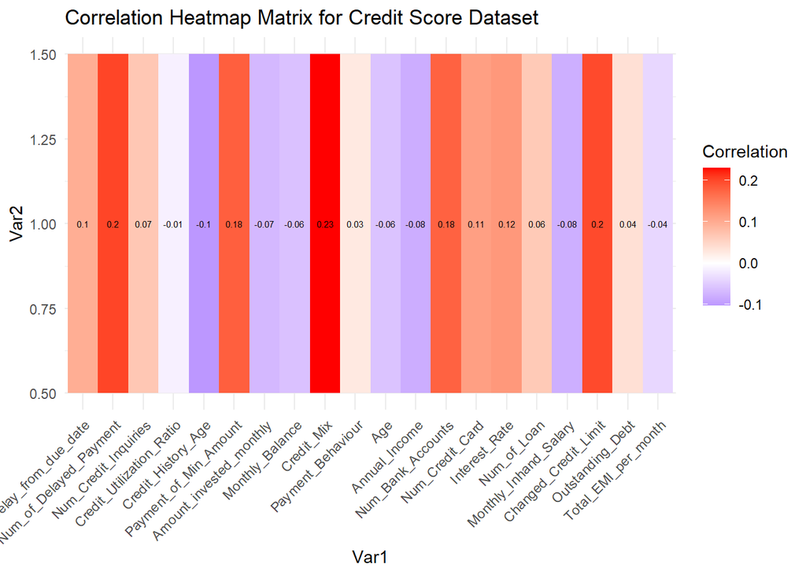

```r
  library(dplyr)

# Convert all features to numeric (except Credit_Score)
train_numeric <- score_dat %>%
  mutate(across(where(is.character), as.numeric)) %>%  # Convert character columns to numeric
  mutate(across(where(is.factor), as.numeric))  # Convert factor columns to numeric

# Convert Credit_Score to numeric for correlation computation
train_numeric$Credit_Score <- as.numeric(as.factor(score_dat$Credit_Score))  # Properly encode Credit_Score

# Compute correlation matrix
cor_matrix <- cor(train_numeric[, -which(names(train_numeric) == "Credit_Score")], train_numeric$Credit_Score)
#print(cor_matrix)

# Convert to DF for ggplot
cor_data_cc <- melt(cor_matrix)

library(ggcorrplot)

# Plot correlation matrix
ggplot(cor_data_cc, aes(x = Var1, y = Var2, fill = value)) +
  geom_tile() +
  geom_text(aes(label = round(value, 2)), color = "black", size = 2) +
  scale_fill_gradient2(low = "blue", mid = "white", high = "red", midpoint = 0) +
  theme_minimal() +
  labs(title = "Correlation Heatmap Matrix for Credit Score Dataset ", fill = "Correlation") +
  theme(axis.text.x = element_text(angle = 45, hjust = 1))
```

## 4.3 Visualization 2 - Bar Chart

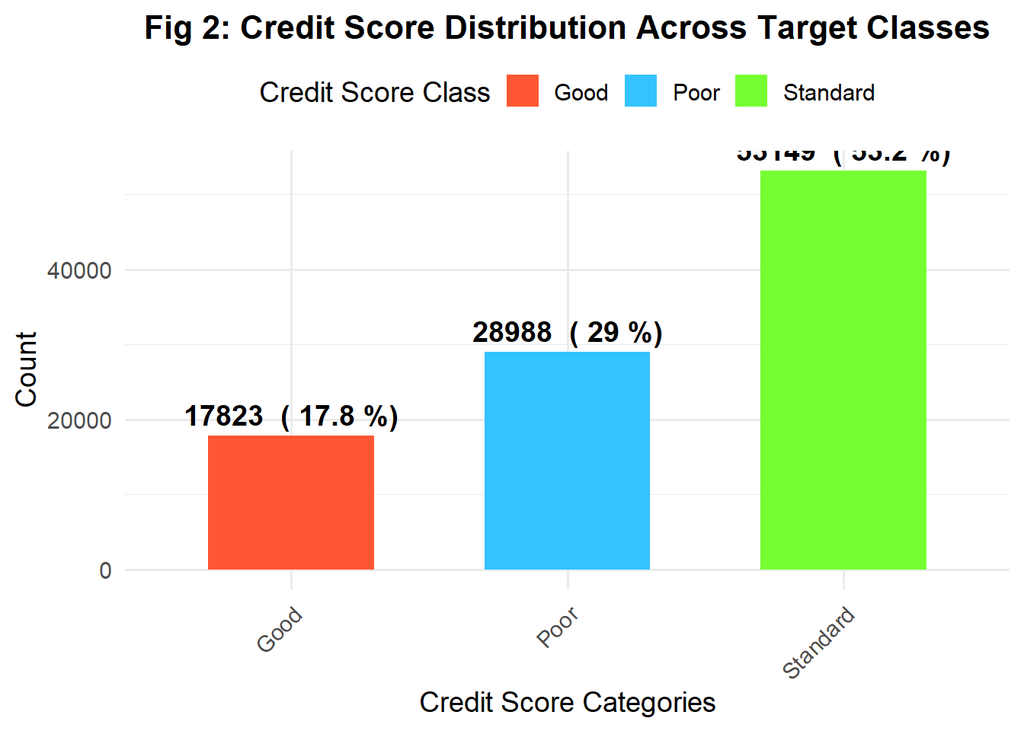

```r
library(ggplot2)
library(dplyr)

# Compute count and percentage for each Credit Score category
score_dat_summary <- score_dat %>%
  count(Credit_Score) %>%
  mutate(Percentage = round(n / sum(n) * 100, 1))

# bar plot with both count and percentage
ggplot(score_dat_summary, aes(x = Credit_Score, y = n, fill = Credit_Score)) +
  geom_bar(stat = "identity", width = 0.6) +  # Adjusted bar width
  geom_text(aes(label = paste(n, " (", Percentage, "%)")), vjust = -0.5, size = 5, fontface = "bold") +  # Adds both count & percentage
  scale_fill_manual(values = c("#FF5733", "#33C3FF", "#75FF33", "#FFD700", "#C70039")) +  # Custom color palette
  labs(
    title = "Fig 2: Credit Score Distribution Across Target Classes",
    #subtitle = "Each bar represents the frequency and percentage of Credit Scores in the dataset",
    x = "Credit Score Categories",
    y = "Count",
    fill = "Credit Score Class"
  ) +
  theme_minimal(base_size = 14) +
  theme(
    plot.title = element_text(hjust = 0.5, face = "bold", size = 16),
    plot.subtitle = element_text(hjust = 0.5, face = "italic"),
    axis.text.x = element_text(angle = 45, hjust = 1),  # Rotates x-axis labels for readability
    legend.position = "top"
  )
```

# 5 Data Preprocessing

Below are the data pre-processing tasks performed

**a)** Separation of Numerical Features into two bassed on cardinality (i.e. unique values)

**b)** Transforming High-Cardinality numeric features by - Box-Cox Transformation : adjust skewed numerical features and make distributions more normal. - Centering & Scaling : standardize numerical variables

**c)** One-Hot Encoding for Categorical Features

**d)** Remove unwanted columns viz. ID, SSN etc.

**e)** Combine all of the pre-processing steps into a single dataframe for further processing in ML models

```r
numeric_df <- score_dat

# Identify low-cardinality numeric columns (≤ 30 unique values)
low_cardinality <- names(numeric_df)[sapply(numeric_df, function(col) length(unique(col)) <= 30)]

# Identify high-cardinality numeric columns (> 30 unique values)
high_cardinality <- names(numeric_df)[sapply(numeric_df, function(col) length(unique(col)) > 30)]
```

```r
# Transformation
recipe_obj <- recipe(~ ., data = score_dat[high_cardinality]) %>%
  step_BoxCox(all_of(high_cardinality)) %>%  # Applies BoxCox to high-cardinality features
  step_center(all_numeric(), -all_outcomes()) %>%  # Centers numeric variables
  step_scale(all_numeric(), -all_outcomes())  # Scales numeric variables

# Prep and apply transformation
prep_recipe <- prep(recipe_obj, training = score_dat[high_cardinality])
numeric <- bake(prep_recipe, score_dat[high_cardinality])

categorical <- c("Payment_of_Min_Amount", "Credit_Mix")

# One-hot encoding
one_hot <- dummy_cols(score_dat[categorical], select_columns = categorical, remove_selected_columns = TRUE)

# Low_cardinality
ordinal <- score_dat[low_cardinality]

# Combines all
score_dat_dp <- cbind(numeric, one_hot, ordinal)

# Removes unwanted columns
score_dat_dp <- score_dat_dp %>% select(-c(Payment_Behaviour, Payment_of_Min_Amount, Credit_Mix))
```

# 6 Feature Engineering

## 6.1 Lasso Regression

Implements Lasso regression for multi-class classification on Credit_Score. It performs feature selection, model training, cross-validation, and accuracy evaluation

**Below are the steps implemented**

**a)** Lambda Range for Regularization - Defines 100 lambda values on a logarithmic scale to cover a wide range of regularization strengths.

**b)** Uses family = “multinomial” for multi-class classification and standardize = TRUE for standardized feature scaling for stability

**c)** Perform Cross-validation to find best Lambda - Cross-validation (cv.glmnet) automatically finds the best regularization strength (lambda).

**d)** Extract Best Lambda and Corresponding Feature Coefficients

**e)** Predicts class labels (type = “class”) for multi-class classification.

**f)** Predicts probability estimates (type = “response”) for confidence scores

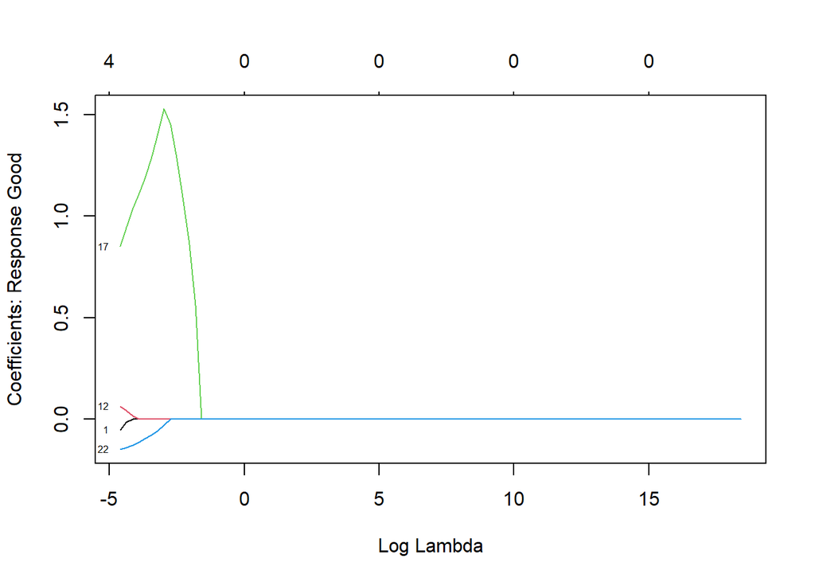

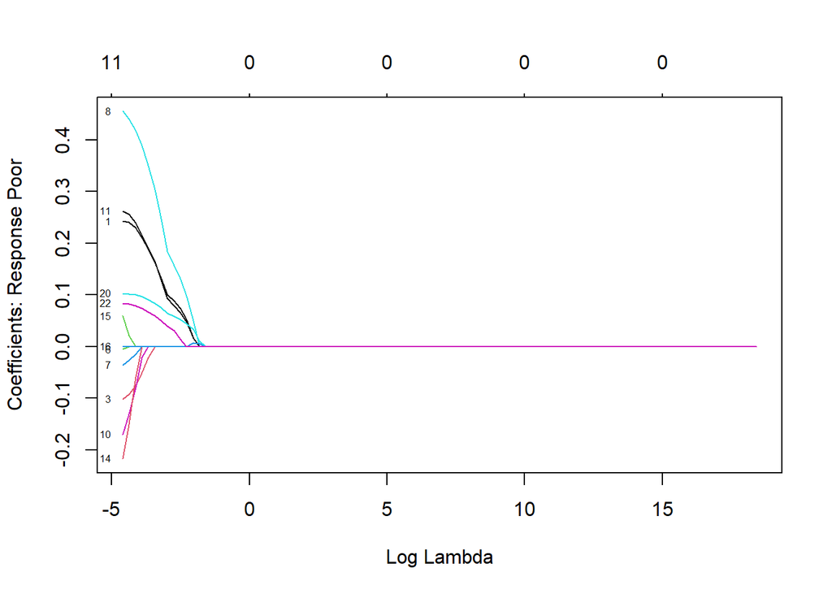

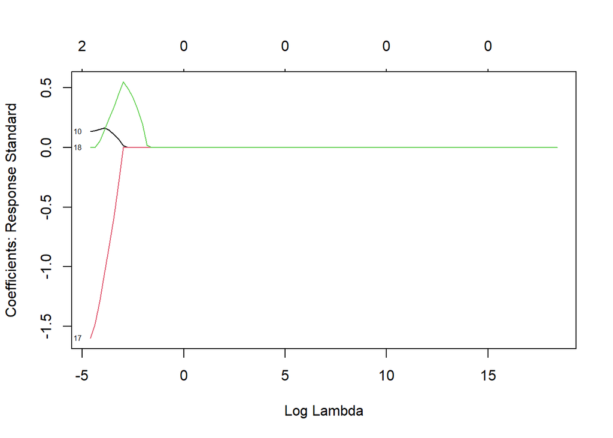

```r
library(glmnet)
library(caret)

# Set seed for reproducibility
set.seed(20250603)

# Split dataset into training and test sets
inTrain_lasso <- createDataPartition(score_dat_dp$Credit_Score, p = 0.6, list = FALSE)
train_lasso <- score_dat_dp[inTrain_lasso,]
test_lasso  <- score_dat_dp[-inTrain_lasso,]

# Target variable for classification
y_train_lasso <- train_lasso$Credit_Score
y_test_lasso  <- test_lasso$Credit_Score

# Convert data to matrix format (exclude Credit_Score)
x_train_lasso <- model.matrix(Credit_Score ~ ., train_lasso)[,-1]
x_test_lasso  <- model.matrix(Credit_Score ~ ., test_lasso)[,-1]

# Define lambda range
grid <- 10^seq(8, -2, length = 100)

# Apply Lasso for Multi-Class Classification
lasso.mod <- glmnet(x_train_lasso, y_train_lasso, alpha = 1, lambda = grid, family = "multinomial", standardize = TRUE)
plot(lasso.mod, xvar = "lambda", label = TRUE)
```

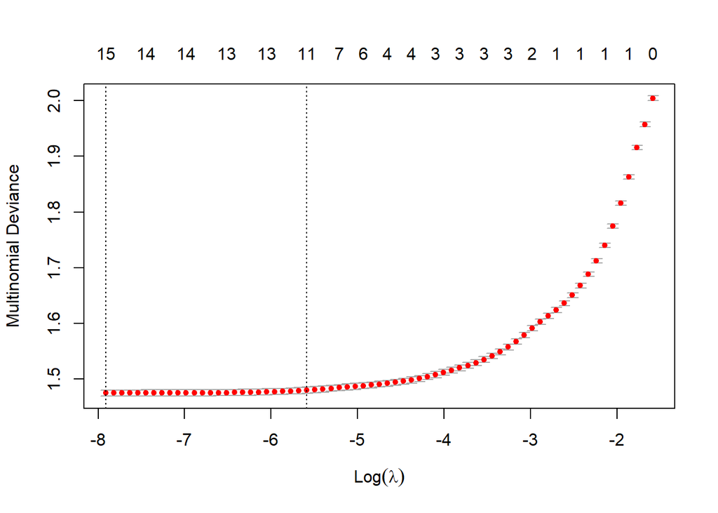

```r
# Perform cross-validation for best lambda
set.seed(20250603)
cv.out <- cv.glmnet(x_train_lasso, y_train_lasso, alpha = 1, family = "multinomial")
plot(cv.out)
```

```r
# Extract optimal lambda value
bestlam <- cv.out$lambda.min
print(paste("Optimal Lambda Value: ",bestlam))
```

```
[1] "Optimal Lambda Value:  0.000366481039996932"
```

```r
# Extract coefficient estimates for best lambda
best.betas <- coef(cv.out, s = bestlam)
print(paste("Coefficient Estimates for the best lambda are :",best.betas))
```

[output not shown]

```r
# Predict on test set (multi-class probabilities)
test.pred <- predict(cv.out, x_test_lasso, s = bestlam, type = "class")  # Class labels
probs <- predict(cv.out, x_test_lasso, s = bestlam, type = "response")   # Probability estimates

# Compute classification accuracy
accuracy <- mean(test.pred == y_test_lasso)
print(paste("Lasso Model Accuracy:", round(accuracy * 100, 2), "%"))
```

```
[1] "Lasso Model Accuracy: 66.06 %"
```

## 6.2 Forward Selection Stepwise (Logistic Regression Multinomial)

Implements forward stepwise feature selection using multinomial logistic regression for multi-class classification of Credit_Score

**Below are the steps implemented**

**a)** Runs stepwise selection for five iterations, progressively adding the best feature.

**b)** Uses selectFeatureMultiClass() to identify the feature that maximizes classification accuracy

**c)** Evaluates feature importance based on classification accuracy.

**d)** Selects the top five features dynamically

**e)** Five most relevant features selected by stepwise feature selection are

**f)** Top 5 Features of Forward Selection Step wise are 1. Interest_Rate

```
      2. Credit_Mix_Good

      3. Num_Credit_Inquiries

      4. Changed_Credit_Limit

      5. Num_Credit_Card"
```

```r
library(nnet)  # For multinomial logistic regression
library(caret)  # For classification evaluation

selectFeatureMultiClass <- function(train, test, cls.train, cls.test, features) {
  current.highest.accuracy <- 0
  selected.i <- NULL

  for(i in 1:ncol(train)) {
    current.f <- colnames(train)[i]

    # Avoid already selected features or target variable
    if(current.f %in% c(features, "Credit_Score")) { next }

    # Fit multinomial logistic regression model using current feature
    model <- multinom(Credit_Score ~ ., data = cbind(train[, c(features, current.f, "Credit_Score")]))

    # Predict on test set
    predictions <- predict(model, test[, c(features, current.f, "Credit_Score")])

    # Compute accuracy
    accuracy <- mean(predictions == cls.test)

    # Update best feature if accuracy improves
    if(accuracy > current.highest.accuracy) {
      current.highest.accuracy <- accuracy
      selected.i <- colnames(train)[i]
    }
  }
  selected.i
}
```

```r
# Load required packages
library(nnet)
library(caret)

# Set seed for reproducibility
set.seed(20250603)

# Split data into training and test sets (Multiclass target: Credit Score)
inTrain <- createDataPartition(score_dat_dp$Credit_Score, p = 0.6, list = FALSE)
train <- score_dat_dp[inTrain,]
test  <- score_dat_dp[-inTrain,]

# Extract target variable
credit_score.train <- train$Credit_Score
credit_score.test <- test$Credit_Score

# Initialize feature selection variables
features.direct <- NULL
current.highest.accuracy <- 0  # Using accuracy for selection

# Find the top five features
for (i in 1:5) {
  selected.i <- selectFeatureMultiClass(train, test, credit_score.train, credit_score.test, features.direct)
  #print(selected.i)

  # Add the best feature from current iteration
  features.direct <- c(features.direct, selected.i)
}
```

```r
print(paste("Top 5 Features of Forward Selection Step wise are :",features.direct))
```

```
[1] "Top 5 Features of Forward Selection Step wise are : Interest_Rate"
[2] "Top 5 Features of Forward Selection Step wise are : Credit_Mix_Good"
[3] "Top 5 Features of Forward Selection Step wise are : Num_Credit_Inquiries"
[4] "Top 5 Features of Forward Selection Step wise are : Changed_Credit_Limit"
[5] "Top 5 Features of Forward Selection Step wise are : Num_Credit_Card"
```

# 7 Classification Algorithms

## 7.1 Logistic Regression (Multinomial)

Implements multinomial logistic regression for multi-class classification of Credit_Score, incorporating cross-validation, prediction, evaluation, and visualization

**Below are the steps implemented**

**a)** Uses 10-fold cross validation

**b)** Trains a multinomial Logistic Regression with “features selected” from Feature Selection

**c)** Evaluation Metrics are 1. Overall Accuracy - **65.34%**

```
      2. Class : Good

            Sensitivity - **69.80%** and Specificity - **86.97%** ;
      3. Class : Poor

          Sensitivity - **52.25%** and Specificity - **88.02%** ;
      4. Class : Standard

          Sensitivity - **70.98%** and Specificity - **67%** ;
```

```r
library(nnet)
library(caret)

set.seed(20250603)  # Ensures reproducibility

# Define cross-validation control
cv_control <- trainControl(method = "cv", number = 10)  # 10-fold CV

# Train logistic regression model using selected features & CV
formula <- as.formula(paste("Credit_Score ~", paste(features.direct, collapse = " + ")))

logistic_cv_model <- train(
  formula,
  data = train,
  method = "multinom",
  trControl = cv_control
)
#print(logistic_cv_model)  # Displays cross-validation results

# Predict on test set
predictions <- predict(logistic_cv_model, test)

# Confusion Matrix & Metrics Calculation
conf_matrix <- confusionMatrix(predictions, test$Credit_Score)

print(conf_matrix)  # Displays accuracy, precision, recall, F1-score
```

```
Confusion Matrix and Statistics

          Reference
Prediction  Good  Poor Standard
  Good      4976  1222     3058
  Poor       289  6058     3112
  Standard  1864  4315    15089

Overall Statistics

               Accuracy : 0.6534
                 95% CI : (0.6487, 0.658)
    No Information Rate : 0.5317
    P-Value [Acc > NIR] : < 2.2e-16

                  Kappa : 0.4292

 Mcnemar's Test P-Value : < 2.2e-16

Statistics by Class:

                     Class: Good Class: Poor Class: Standard
Sensitivity               0.6980      0.5225          0.7098
Specificity               0.8697      0.8802          0.6700
Pos Pred Value            0.5376      0.6404          0.7095
Neg Pred Value            0.9299      0.8186          0.6703
Prevalence                0.1783      0.2900          0.5317
Detection Rate            0.1245      0.1515          0.3774
Detection Prevalence      0.2315      0.2366          0.5319
Balanced Accuracy         0.7839      0.7013          0.6899
```

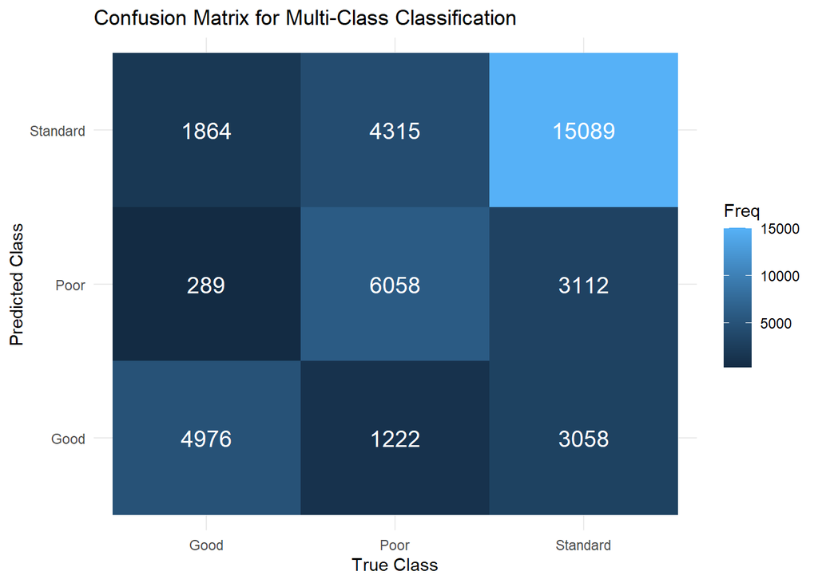

```r
library(ggplot2)

# Convert confusion matrix to data frame
conf_df <- as.data.frame(conf_matrix$table)

# Plot Confusion Matrix
ggplot(conf_df, aes(x = Reference, y = Prediction, fill = Freq)) +
  geom_tile() +
  geom_text(aes(label = Freq), color = "white", size = 5) +
  labs(title = "Confusion Matrix for Multi-Class Classification",
       x = "True Class",
       y = "Predicted Class") +
  theme_minimal()
```

## 7.2 Random Forest Feature Selection + Training & Test

Implements feature selection, model training, evaluation, and prediction using Random Forest for multi-class classification of Credit_Score

**Below are the steps implemented**

**a)** Fits a Random Forest model (ntree = 500) to determine feature importance.

**b)** Enables importance = TRUE to retrieve significant features

**c)** Ranks features based on their importance to classification and filters out Top 5 features for model training and test ; **Top 5 features are** 1. Delay_from_due_date 2. Num_Credit_Card 3. Total_EMI_per_month 4. Age 5. Annual_Income

**d)** Evaluation Metrics are 1. Overall Accuracy - **77.78%**

```
      2. Class : Good

            Sensitivity - **73.33%** and Specificity - **94.14%** ;
      3. Class : Poor

          Sensitivity - **80.97%** and Specificity - **89.79%** ;
      4. Class : Standard

          Sensitivity - **77.53%** and Specificity - **78.31%** ;
```

```r
library(randomForest)
library(caret)

set.seed(20250603)

# Split dataset into training and test sets
inTrain_rf <- createDataPartition(score_dat_dp$Credit_Score, p = 0.6, list = FALSE)
train_rf <- score_dat_dp[inTrain_rf,]
test_rf  <- score_dat_dp[-inTrain_rf,]

# Convert target to factor for classification
# train$Credit_Score <- as.factor(train$Credit_Score)
# test$Credit_Score  <- as.factor(test$Credit_Score)

# Train initial Random Forest model to get feature importance
rf_feature_model <- randomForest(Credit_Score ~ ., data = train_rf, ntree = 500, importance = TRUE)

# Extract feature importance scores
feature_importance <- importance(rf_feature_model)

# Select top 5 most important features
selected_features <- names(sort(feature_importance[, 1], decreasing = TRUE))[1:5]
print(selected_features)
```

```
[1] "Delay_from_due_date" "Num_Credit_Card"     "Total_EMI_per_month"
[4] "Age"                 "Annual_Income"
```

```r
# Create formula using selected features
formula_rf <- as.formula(paste("Credit_Score ~", paste(selected_features, collapse = " + ")))

# Train Random Forest model using only selected features
set.seed(20250603)
rf_model <- randomForest(formula_rf, data = train_rf, ntree = 500)

# Predict on test set
rf_pred <- predict(rf_model, test_rf)

# Compute accuracy
accuracy_rf <- mean(rf_pred == test_rf$Credit_Score)
print(paste("Random Forest Accuracy:", round(accuracy_rf * 100, 2), "%"))
```

```
[1] "Random Forest Accuracy: 77.78 %"
```

```r
library(caret)

# Generate confusion matrix for multi-class evaluation
conf_matrix_rf <- confusionMatrix(rf_pred, test_rf$Credit_Score)

# Print evaluation metrics
print(conf_matrix_rf)
```

```
Confusion Matrix and Statistics

          Reference
Prediction  Good  Poor Standard
  Good      5228    30     1894
  Poor        16  9388     2882
  Standard  1885  2177    16483

Overall Statistics

               Accuracy : 0.7778
                 95% CI : (0.7737, 0.7819)
    No Information Rate : 0.5317
    P-Value [Acc > NIR] : < 2.2e-16

                  Kappa : 0.6332

 Mcnemar's Test P-Value : < 2.2e-16

Statistics by Class:

                     Class: Good Class: Poor Class: Standard
Sensitivity               0.7333      0.8097          0.7753
Specificity               0.9414      0.8979          0.7831
Pos Pred Value            0.7310      0.7641          0.8023
Neg Pred Value            0.9421      0.9203          0.7543
Prevalence                0.1783      0.2900          0.5317
Detection Rate            0.1308      0.2348          0.4123
Detection Prevalence      0.1789      0.3073          0.5138
Balanced Accuracy         0.8374      0.8538          0.7792
```

## 7.3 Random Forest Visualisation (Confusion Matrix)

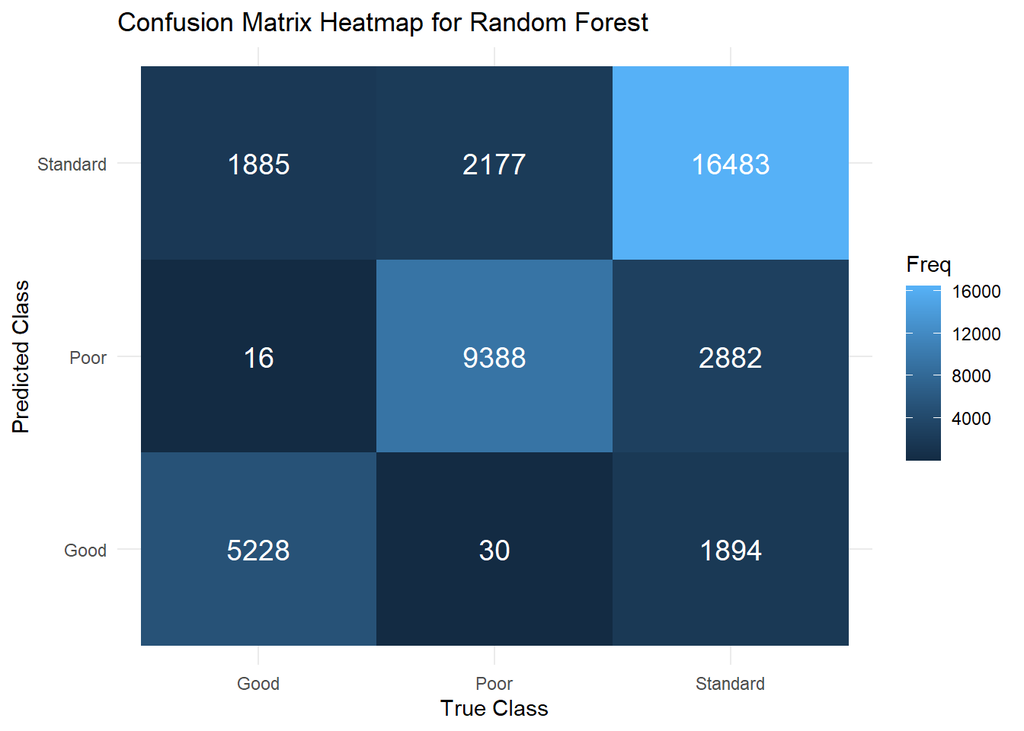

```r
# Convert confusion matrix to data frame for visualization
conf_df <- as.data.frame(conf_matrix_rf$table)

# Create a heatmap plot
ggplot(conf_df, aes(x = Reference, y = Prediction, fill = Freq)) +
  geom_tile() +
  geom_text(aes(label = Freq), color = "white", size = 5) +
  labs(title = "Confusion Matrix Heatmap for Random Forest",
       x = "True Class",
       y = "Predicted Class") +
  theme_minimal()
```

## 7.4 XGBoost Feature Selection

Implements XGBoost for multi-class classification of Credit_Score, including data preprocessing, model training, feature importance extraction, and evaluation

**Below are the steps implemented**

**a)** Converts categorical variables into dummy variables for XGBoost. Ensures target variable (Credit_Score) is converted to numeric format .

**b)** Uses multi:softmax to assign discrete class labels.

**c)** Defines mlogloss as the evaluation metric to minimize classification errors

**d)** Trains the XGBoost model for 100 rounds (nrounds = 100).

**e)** Optimizes classification performance using gradient boosting

**f)** Ranks Top 5 features by their impact on reducing classification error. They are as below **Top 5 features are** 1. Outstanding_Debt 2. Credit_Mix_Good 3. Credit_Mix_Standard 4. Interest_Rate 5. Changed_Credit_Limit

```r
library(xgboost)
library(caret)

set.seed(20250604)

# Convert target to factor for multi-class classification
# train$Credit_Score <- as.factor(train$Credit_Score)
# test$Credit_Score  <- as.factor(test$Credit_Score)

# Split dataset into training and test sets
inTrain_xgb <- createDataPartition(score_dat_dp$Credit_Score, p = 0.6, list = FALSE)
train_xgb <- score_dat_dp[inTrain_xgb,]
test_xgb  <- score_dat_dp[-inTrain_xgb,]

# Convert target to factor for classification
# train$Credit_Score <- as.factor(train$Credit_Score)
# test$Credit_Score  <- as.factor(test$Credit_Score)

# Convert data to matrix format for XGBoost
x_train_xgb <- model.matrix(Credit_Score ~ ., train_xgb)[,-1]
x_test_xgb  <- model.matrix(Credit_Score ~ ., test_xgb)[,-1]
y_train_xgb <- as.numeric(train_xgb$Credit_Score) - 1  # XGBoost requires numeric labels
y_test_xgb  <- as.numeric(test_xgb$Credit_Score) - 1

# Convert dataset into XGBoost format
dtrain <- xgb.DMatrix(data = x_train_xgb, label = y_train_xgb)
dtest  <- xgb.DMatrix(data = x_test_xgb, label = y_test_xgb)

# Define XGBoost parameters for multi-class classification
params <- list(
  objective = "multi:softmax",
  num_class = length(unique(y_train_xgb)),
  eval_metric = "mlogloss"
)

# Train XGBoost model
xgb_model <- xgb.train(params, data = dtrain, nrounds = 100, verbose = FALSE)

# Extract feature importance
feature_importance_xgb <- xgb.importance(model = xgb_model)

# Select Top 5 Important Features
selected_features_xgb <- feature_importance_xgb$Feature[1:5]
print(selected_features_xgb)
```

```
[1] "Outstanding_Debt"     "Credit_Mix_Good"      "Credit_Mix_Standard"
[4] "Interest_Rate"        "Changed_Credit_Limit"
```

## 7.5 XGBoost Training & Test

Filters selected features, retrains an XGBoost model with those features, makes predictions, computes accuracy, and evaluates performance using a confusion matrix

**Below are the steps implemented**

**a)** Uses only the most important features (selected_features_xgb) identified in the previous step. Thus, reduces dimensionality, improving efficiency and interpretability

**b)** Retrains XGBoost using only selected features.

**c)** Uses nrounds = 100 boosting rounds to improve classification accuracy

**d)** Evaluation Metrics are 1. Overall Accuracy - **74.23%**

```
      2. Class 0 : Good

            Sensitivity - **77.16%** and Specificity - **88.64%** ;
      3. Class 1 : Poor

          Sensitivity - **69.44%** and Specificity - **91.38%** ;
      4. Class 2 : Standard

          Sensitivity - **75.85%** and Specificity - **77.96%** ;
```

```r
# Filter training and test sets using selected features
x_train_selected <- train_xgb[, selected_features_xgb]
x_test_selected  <- test_xgb[, selected_features_xgb]

dtrain_selected <- xgb.DMatrix(data = as.matrix(x_train_selected), label = y_train_xgb)
dtest_selected  <- xgb.DMatrix(data = as.matrix(x_test_selected), label = y_test_xgb)

# Retrain model using only selected features
xgb_selected_model <- xgb.train(params, data = dtrain_selected, nrounds = 100, verbose = FALSE)

# Predict on test set
xgb_pred <- predict(xgb_selected_model, dtest_selected)

# Compute accuracy
accuracy_xgb <- mean(xgb_pred == y_test_xgb)
print(paste("XGBoost Model Accuracy (After Feature Selection):", round(accuracy_xgb * 100, 2), "%"))
```

```
[1] "XGBoost Model Accuracy (After Feature Selection): 74.23 %"
```

```r
# Compute confusion matrix
conf_matrix_xgb <- confusionMatrix(factor(xgb_pred), factor(y_test_xgb))

# Print evaluation results
print(conf_matrix_xgb)
```

```
Confusion Matrix and Statistics

          Reference
Prediction     0     1     2
         0  5501  1015  2716
         1    29  8052  2418
         2  1599  2528 16125

Overall Statistics

               Accuracy : 0.7423
                 95% CI : (0.7379, 0.7465)
    No Information Rate : 0.5317
    P-Value [Acc > NIR] : < 2.2e-16

                  Kappa : 0.5798

 Mcnemar's Test P-Value : < 2.2e-16

Statistics by Class:

                     Class: 0 Class: 1 Class: 2
Sensitivity            0.7716   0.6944   0.7585
Specificity            0.8864   0.9138   0.7796
Pos Pred Value         0.5959   0.7669   0.7962
Neg Pred Value         0.9471   0.8798   0.7398
Prevalence             0.1783   0.2900   0.5317
Detection Rate         0.1376   0.2014   0.4033
Detection Prevalence   0.2309   0.2626   0.5065
Balanced Accuracy      0.8290   0.8041   0.7690
```

# 8 Classification Performance Evaluation

## 8.1 Logistic Regression (multinomial)

**Evaluation Metrics are** 1. Overall Accuracy - **65.34%**

```
      2. Class : Good

            Sensitivity - **69.80%** and Specificity - **86.97%** ;
      3. Class : Poor

          Sensitivity - **52.25%** and Specificity - **88.02%** ;
      4. Class : Standard

          Sensitivity - **70.98%** and Specificity - **67%** ;
```

## 8.2 Random Forest

**Evaluation Metrics are** 1. Overall Accuracy - **77.78%**

```
      2. Class : Good

            Sensitivity - **73.33%** and Specificity - **94.14%** ;
      3. Class : Poor

          Sensitivity - **80.97%** and Specificity - **89.79%** ;
      4. Class : Standard

          Sensitivity - **77.53%** and Specificity - **78.31%** ;
```

## 8.3 XGBoost

**Evaluation Metrics are** 1. Overall Accuracy - **74.23%**

```
      2. Class 0 : Good

            Sensitivity - **77.16%** and Specificity - **88.64%** ;
      3. Class 1 : Poor

          Sensitivity - **69.44%** and Specificity - **91.38%** ;
      4. Class 2 : Standard

          Sensitivity - **75.85%** and Specificity - **77.96%** ;
```

# 9 Conclusion

Considering all performance metrics as above , **Random Forest** is the most effective model for solving this multi-class classification problem.